# CaseStudy2_Attrition

Paul Adams

August 10, 2019

### GitHub Repository: https://github.com/PaulAdams4361/SMU-Case-Study-2

### PowerPoint presentation: https://youtu.be/803OW_EOIbc

# Executive Summary

### The following is report produced on behalf of DDSAnalytics to highlight major factors contributing to attrition, as well as to predict attrition based on the current employees at Frito Lay. This report is in effort to assist talent management develop and retain employees, including resource investment on workforce planning, employee training, and other initiatives. Because these investments are expensive, DDSAnalytics would like help Frito Lay minimize preventable attrition.

# Introduction

### Frito Lay has gathered a large quantity of employee data, which ranges from attrition to pay raise percentages, years of employment, salary, and much more. Altogether, DDSAnalytics was provided with 34 predictor variables and accompanying attrition statuses, denoted as “Yes” and “No.” With this data, we sought out to predict whether an employee is likely to leave their company (indicated as a “Yes” for attrition) given their current status, based on the 34 variables, or is likely to remain employed at the company (indicated by a “No”). While many of the 34 variables were used in this analysis, many others required transformations; refactoring; and even elimination since many were unnecessary or closely related to a more descriptive, comparable variable. For an example of variable elimination, the variable for “years in current role” was removed in favor of “years at company” since these were highly correlated with each other in the data set, but “years at company” more descriptive since it allows for employees to change jobs without increasing attrition. In another example, for variable transformation, “monthly income” was logarithmically transformed to better approximate a normal distribution that would be more reliable in statistical computation. For an example using refactoring, the categorical “business travel” variable, comprised of “Non-Travel,” “Travel_Rarely,” and “Travel_Frequently,” were transformed into 0 (for non-travel, since it does not exist), 1 for travel rarely, and 2 for travel frequently, which allowed for better mathematical consideration within the predictive models. After tuning the prediction models and variables, this was determined a best approach.

# Ingest and wrangle the data

```r
library(pacman)
```

```r
p_load(readr, dplyr, stats,tidyverse, ggthemes, RColorBrewer, gplots, RColorBrewer, ggplot2, corrplot, cowplot, skimr, randomForest, caret, MASS, Hmisc, permuco, e1071, dummies, openxlsx)

# red in the data
data.Employee <- read.csv('./CaseStudy2-data.csv', header=T, sep=",", strip.white=T) %>%
  data.frame()

data.Employee.Regression <- read.csv('./CaseStudy2-data.csv', header=T, sep=",", strip.white=T) %>% data.frame()

data.Test.Attrition <- read.csv('./CaseStudy2CompSet No Attrition.csv', header=T, sep=",", strip.white=T) %>% data.frame()

data.Test.Income <- read.xlsx('./CaseStudy2CompSet No Salary.xlsx') %>% data.frame()

data.nonTransformed <- read.csv('./CaseStudy2-data.csv', header=T, sep=",", strip.white=T) %>% data.frame()

# Get an understanding of the data size
dim(data.Employee)

# Identify all NAs to impute (or remove) as needed
na_count <- sapply(data.Employee, function(cnt) sum(length(which(is.na(cnt)))))
na_count

# Look into the data structure for class types and levels
str(data.Employee)

# Converting all char classes to factor and all int classes to numeric for uniformity in processing and predicting
data.Employee <- data.Employee %>% mutate_if(is.integer, as.numeric) %>% mutate_if(is.character, as.factor) %>% data.frame()

# Remove all factors with only one level and ID
data.Employee <- data.Employee %>% subset(select=c(-ID, -Over18, -StandardHours, -EmployeeCount))

# Make sure structure updated without issue
#str(data.Employee)
```

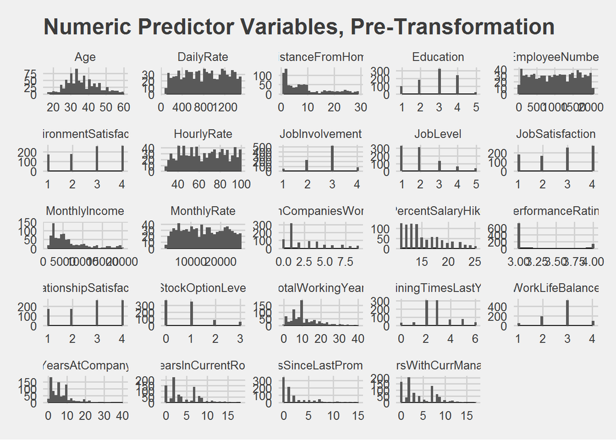

```r
# Histogram distributions before transformations
data.Employee %>% keep(is.numeric) %>%
  gather() %>%
  ggplot(aes(x=value)) +
  facet_wrap(~ key, scales = "free") +
  geom_density() +
  geom_histogram(binwidth = NULL) +
  theme_fivethirtyeight() +
  ggtitle("Numeric Predictor Variables, Pre-Transformation")
```

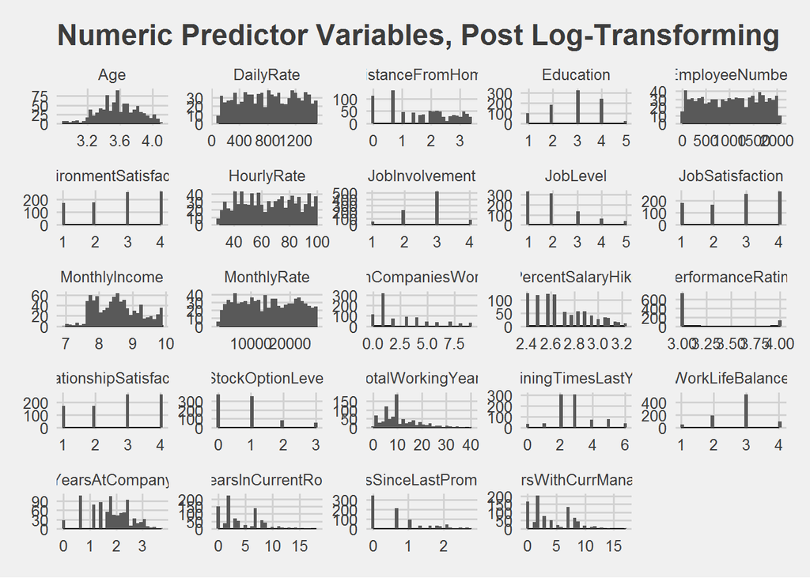

```r
#convert ranges
data.Employee$MonthlyIncome <- log(data.Employee$MonthlyIncome)
data.Employee$YearsAtCompany <- log(data.Employee$YearsAtCompany+1)
data.Employee$Age <- log(data.Employee$Age)
data.Employee$DistanceFromHome <- log(data.Employee$DistanceFromHome)
data.Employee$PercentSalaryHike <- log(data.Employee$PercentSalaryHike)
data.Employee$YearsSinceLastPromotion <- log(data.Employee$YearsSinceLastPromotion+1)


# After transformations
data.Employee %>%keep(is.numeric) %>%
  gather() %>%
  ggplot(aes(x=value)) +
  facet_wrap(~ key, scales = "free") +
  geom_density() +
  geom_histogram(binwidth = NULL) +
  theme_fivethirtyeight() +
  ggtitle("Numeric Predictor Variables, Post Log-Transforming")
```

# Job Role Question: Identify Job Roles by Attrition Proportion

### As requested, we performed an breakdown of attrition by job role. What we found is that sales representatives are by far the group most likely to change companies, with roughly twice as much likelihood as the next closest job role, followed closely by those in Human Resources, then Lab Technicians, Research Scientists, and Sales Executives. Both Research Directors and Manufacturing Directors are the least likely to change companies.

Because there are only 51 Research Directors, and only one of them has left their company, there is not much data to use for inference. Furthermore, of 87 Manufacturing Directors, only two have left their company. Nonetheless, this possibly indicates a high level of job satisfaction for these roles.

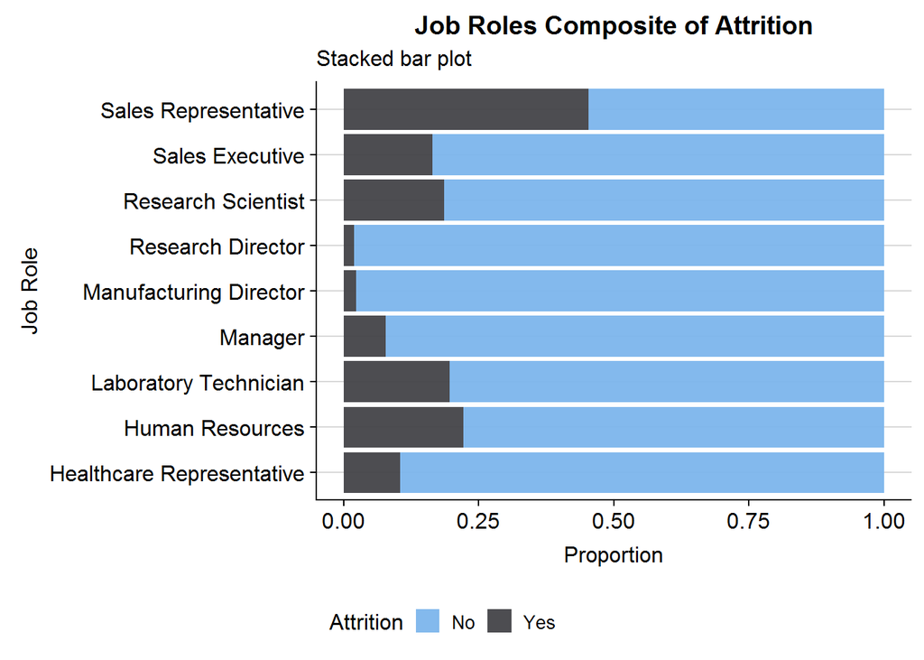

```r
ggplot(data.Employee, aes(x=JobRole, fill = Attrition)) +
  geom_bar(alpha=0.95, position = "fill") +
  coord_flip() +
  labs(x = "Job Role", y = "Proportion", title = "Job Roles Composite of Attrition",
       subtitle = "Stacked bar plot") +
  theme_hc() +
  scale_fill_hc()
```

# Job Role Question: Key Factors in Sale Representatives’ High Turnover

### Identified later in this report, we identified that the two highest employee turnover factors are age and monthly income. Therefore, we identified sales representatives who have high and low turnover and segmented them based on age and monthly income.

There is significant overlap when comparing groups of employees who have quit and those who have not. However, something distinctive is that of the employees who have not quit, about 75% earn more than 2,000-dollar monthly income, whereas of those who have quit, 25% earn less than 2,000 dollars.

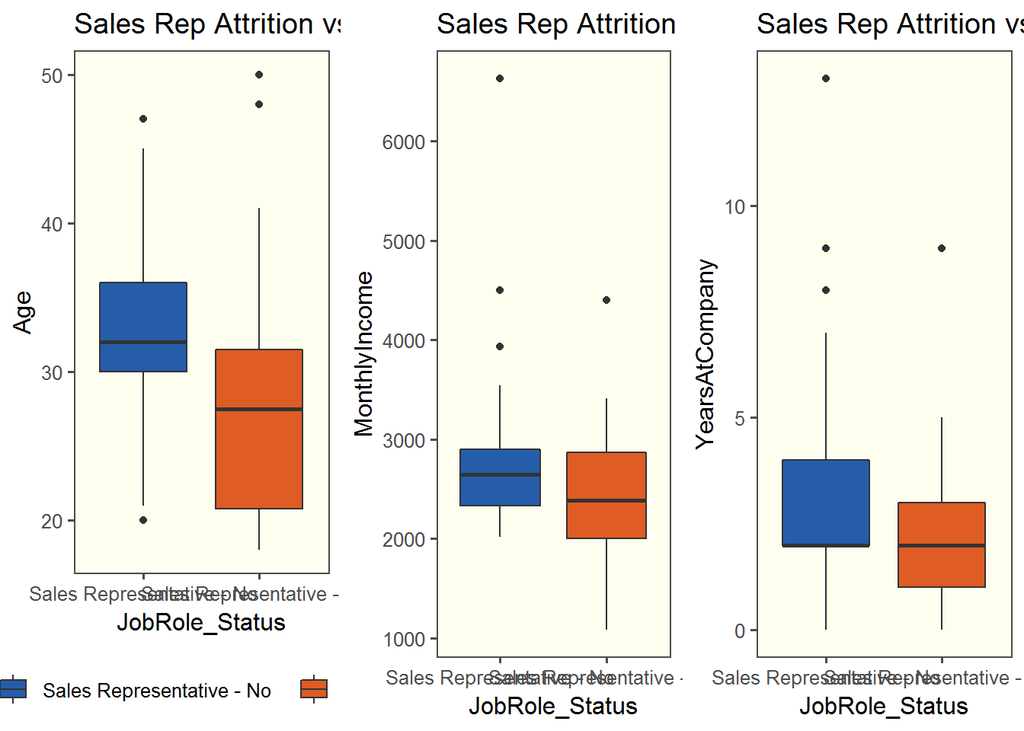

```r
###################################################################################
########### Breaking Down the impact of Age on JobRole Attrition status ###########
###################################################################################

# Creating variables to merge job role and attrition status in a dataframe with age for ggplot2:
repRole <- data.nonTransformed[which(data.nonTransformed$JobRole == "Sales Representative"),"JobRole"] %>% data.frame()
repAge <- data.nonTransformed[which(data.nonTransformed$JobRole == "Sales Representative"),"Age"] %>% data.frame()
repAttrition <- data.nonTransformed[which(data.nonTransformed$JobRole == "Sales Representative"),"Attrition"] %>% data.frame()
repMoIncome <- data.nonTransformed[which(data.nonTransformed$JobRole == "Sales Representative"),"MonthlyIncome"] %>% data.frame()
repCoYears <- data.nonTransformed[which(data.nonTransformed$JobRole == "Sales Representative"),"YearsAtCompany"] %>% data.frame()

# create dataframe with the variables
repHolder <- data.frame(repRole, repAttrition,repAge, repMoIncome, repCoYears)

# rename the columns
colnames(repHolder) <- c("JobRole","Attrition","Age", "MonthlyIncome", "YearsAtCompany")

# create the job role status "jobrole - attrition"
JobRole_Status <- paste(as.character(repHolder$JobRole), "-", as.character(repHolder$Attrition))

# final assembly dataframe with the new variables for sales representatives
JobRole_Age_Attrition_df <- data.frame(JobRole_Status, repHolder$Age, repHolder$MonthlyIncome, repHolder$YearsAtCompany)

# rename the columns
colnames(JobRole_Age_Attrition_df) <- c("JobRole_Status","Age","MonthlyIncome", "YearsAtCompany")

########################################################JobRole = Sales Rep
# ggplot for job role attrition vs. age
x1 <- ggplot(data = JobRole_Age_Attrition_df, aes(x = JobRole_Status, y = Age, fill = JobRole_Status)) + geom_boxplot() + scale_fill_few(palette = "Dark") + theme_few() + ggtitle("Sales Rep Attrition vs. Age") + theme(panel.background = element_rect(fill = 'ivory1'),legend.position="bottom")

# ggplot for job role attrition vs. income

x2 <- ggplot(data = JobRole_Age_Attrition_df, aes(x = JobRole_Status, y = MonthlyIncome, fill = JobRole_Status)) + geom_boxplot() + scale_fill_few(palette = "Dark") + theme_few() + ggtitle("Sales Rep Attrition vs. Monthly Income") + theme(panel.background = element_rect(fill = 'ivory1'),legend.position="none")

# ggplot for job role attrition vs. years at company

x3 <- ggplot(data = JobRole_Age_Attrition_df, aes(x = JobRole_Status, y = YearsAtCompany, fill = JobRole_Status)) + geom_boxplot() + scale_fill_few(palette = "Dark") + theme_few() + ggtitle("Sales Rep Attrition vs. Years at Company") + theme(panel.background = element_rect(fill = 'ivory1'),legend.position="none")

par(oma=c(0.1,0.1,2.1,0))
plot_grid(x1,x2,x3, ncol = 3, rel_widths = c(1,1,1))
```

```r
###########################################################################
```

# Indicator Values and Variable Recoding

### Because many of our variables had categorical levels, I split them out into indicator variables where their presence is represented as 1s and 0s when present or not, respectively. This practice is also called one-hot encoding and if done in excess can cause overfitting problems with the model as the parameters selected influence output values, such as adjusted r-squared and p-values. As a result, I recoded ordinal categories into numerical sequences and recoded the presence or lack of a variable - such as yes/no - as 1s and 0s; when present, the value will impact the model, but when not, there will be no direct influence from the variable represented with a zero.

```r
data.Employee2 <- data.Employee

#############################################################################
########################## Department dummy variable creation################
#############################################################################
Department <- data.frame(data.Employee2$Department)
Department <- suppressWarnings(dummy.data.frame(Department))
#levels(data.Employee2$Department)
colnames(Department) <- c("Department.HumanResources","Department.ResearchDevelopment","Department.Sales")

data.Employee2 <- cbind(data.Employee2,Department)
data.Employee2 <- data.Employee2 %>% subset(select=-Department)
#colnames(data.Employee2)
#############################################################################
#############################################################################
#############################################################################

#############################################################################
########################## Education Field dummy variable creation###########
#############################################################################
EducationField <- data.frame(data.Employee2$EducationField)
EducationField <- suppressWarnings(dummy.data.frame(EducationField))
#levels(data.Employee2$EducationField)
colnames(EducationField) <- c("Educ.HumanResources","Educ.LifeSciences","Educ.Marketing","Educ.Medical","Educ.Other","Educ.TechnicalDegree")

data.Employee2 <- cbind(data.Employee2,EducationField)
data.Employee2 <- data.Employee2 %>% subset(select=-EducationField)
#colnames(data.Employee2)
############################################################################
############################################################################
############################################################################

#############################################################################
########################## Job Role dummy variable creation##################
#############################################################################
JobRole <- data.frame(data.Employee2$JobRole)
JobRole <- suppressWarnings(dummy.data.frame(JobRole))
#levels(data.Employee2$JobRole)
colnames(JobRole) <- c("Job.HealthcareRepresentative","Job.HumanResources","Job.LaboratoryTechnician","Job.Manager","Job.ManufacturingDirector","Job.ResearchDirector","Job.ResearchScientist","Job.SalesExecutive","Job.SalesRepresentative")

data.Employee2 <- cbind(data.Employee2,JobRole)
data.Employee2 <- data.Employee2 %>% subset(select=-JobRole)
#colnames(data.Employee2)
############################################################################
############################################################################
############################################################################

############################################################################
########################## Gender dummy variable creation###################
############################################################################
Gender <- data.frame(data.Employee2$Gender)
Gender <- suppressWarnings(dummy.data.frame(Gender))
#levels(data.Employee2$JobRole)
colnames(Gender) <- c("Male","Female")

data.Employee2 <- cbind(data.Employee2,Gender)
data.Employee2 <- data.Employee2 %>% subset(select=-Gender)
#colnames(data.Employee2)
############################################################################
############################################################################
############################################################################

# Recode BusinessTravel with numerical representation of ordinal factor levels
data.Employee2$BusinessTravel <- dplyr::recode(data.Employee2$BusinessTravel, `Non-Travel`="0", `Travel_Rarely`="1", `Travel_Frequently`="2")

# Recode MaritalStatus with numerical representation of ordinal factor levels
data.Employee2$MaritalStatus <- dplyr::recode(data.Employee2$MaritalStatus, `Single`="1", `Married`="2", `Divorced`="3")

# Recode OverTime with numerical representation of ordinal factor levels
data.Employee2$OverTime <- dplyr::recode(data.Employee2$OverTime, `Yes`="1", `No`="0")

# Recode Attrition with numerical representation of ordinal factor levels
#data.Employee2$Attrition <- dplyr::recode(data.Employee2$Attrition, `Yes`="1", `No`="0")

data.Employee2$BusinessTravel <- as.integer(data.Employee2$BusinessTravel)
data.Employee2$MaritalStatus <- as.integer(data.Employee2$MaritalStatus)
data.Employee2$OverTime <- as.integer(data.Employee2$OverTime)
```

# First Correlation Plot: Pre-Variable Elimination

### Displayed is a `correlation plot` for the predictor variables. `Indicator variables` have a period (`.`) in the name. For each strongly, positively correlated pair of variables identified - excluding those from dummy variable creation, unless all share similar strong correlation - the less descriptive variable will be removed from the pair to prevent overfitting the model.

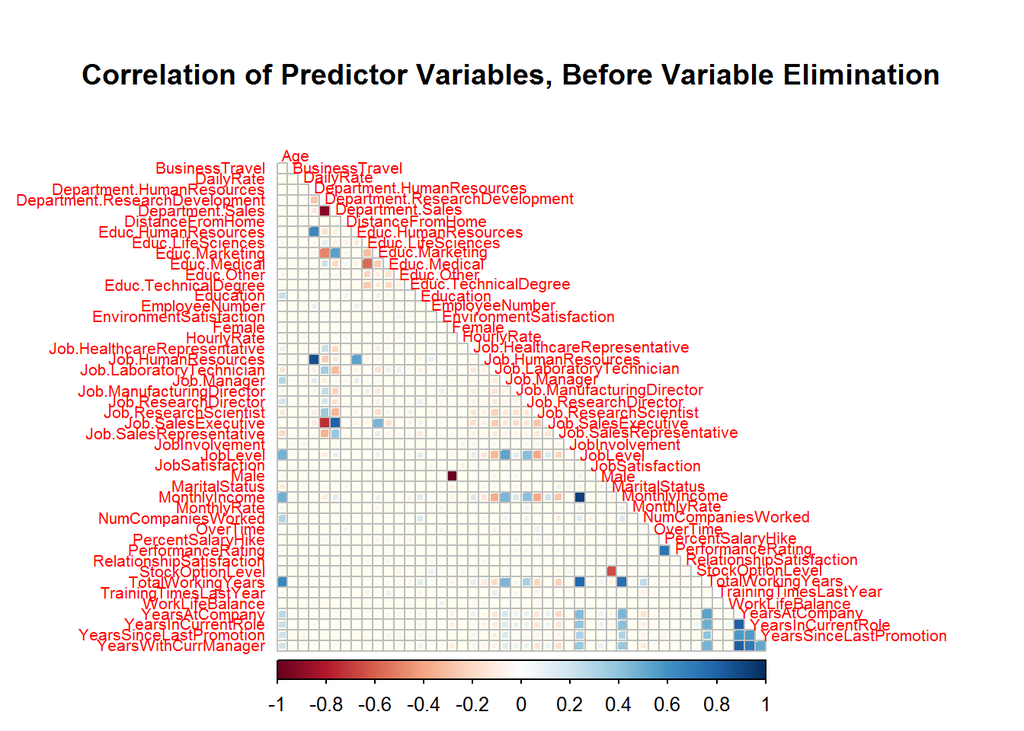

```r
#####################################################################################
#################### Start Corrplot for Non-Transformed Data ########################
#####################################################################################

# Correlation plot to see correlation among predictor variables, excluding Attrition (the response)
data.Employee.numeric <- data.Employee2  %>% subset(select=-Attrition)

corrplot(cor(data.Employee.numeric)
         , title = "Correlation of Predictor Variables, Before Variable Elimination"
         , type = "lower"
         , tl.pos = "ld"
         , method = "square"
         , tl.cex = 0.65
         , tl.col = 'red'
         , order = "alphabet"
         , diag = F
         , mar=c(0,0,5,0)
         , bg="ivory1"
         ,tl.srt=.05
         )
```

```r
#####################################################################################
#################### Exit Corrplot for Non-Transformed Data #########################
#####################################################################################
```

# Remove Unnecessary Predictor Variables

### Here, predictor variables that have high correlation with stronger predictor variables are removed for collinearity. This will help prevent overfitting. Also, all factors are converted to integer.

### Variables Removed:

#### 1) `JobLevel` has been removed in favor of `MonthlyIncome`; `MonthlyIncome` is more descriptive with more levels.

#### 2) `TotalWorkingYears` has been removed in favor of `Age`; Age more closely approximates normality (less skewedness) and should behave better under that assumption.

#### 3) `PerformanceRating` has been removed in favor of `PercentSalaryHike`; `PerformanceRating` only has two levels.

#### 4) `YearsInCurrentRole` has been removed in favor of `YearsAtCompany`; `YearsAtCompany` has slightly less cross-correlation with other variables.

#### 5) `YearsWithCurrManager` has been removed in favor of `YearsAtCompany`; `YearsAtCompany` is always greater than or equal to `YearsWithCurrManager` since someone can change teams or departments, but remain employed at the company.

```r
#Remove cross-correlated predictor variables
data.Employee.varFiltered <- data.Employee2 %>% subset(select = c(-JobLevel, -TotalWorkingYears, -PerformanceRating, -YearsInCurrentRole, -YearsWithCurrManager))

# Make sure they're gone
#str(data.Employee.varFiltered)
```

# Second Correlation Plot, post-Variable Elimination

### A second correlation plot to display correlations among remaining variables indicates the strongest remaining correlations between predictor variables are for those who belong to variables that have had their levels recoded as indicator variables. These correlations are necessary to include in the model because eliminating them would provide a misleading fit for any models produced.

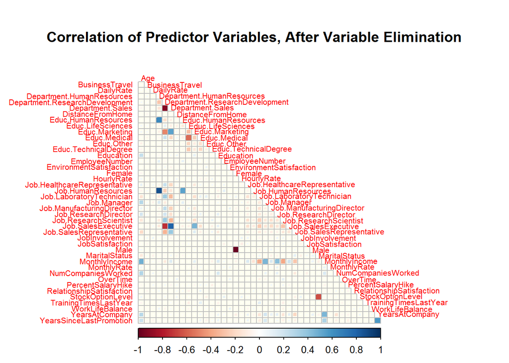

```r
# Display without response variable, Attrition
data.employee.numeric2 <- data.Employee.varFiltered %>% subset(select=-Attrition)

corrplot(cor(data.employee.numeric2)
         , title = "Correlation of Predictor Variables, After Variable Elimination"
         , type = "lower"
         , tl.pos = "ld"
         , method = "square"
         , tl.cex = 0.65
         , tl.col = 'red'
         , order = "alphabet"
         , diag = F
         , mar=c(0,0,5,0)
         , bg="ivory1"
         ,tl.srt=.05
         )
```

# Random Forest Variable Importance Plot

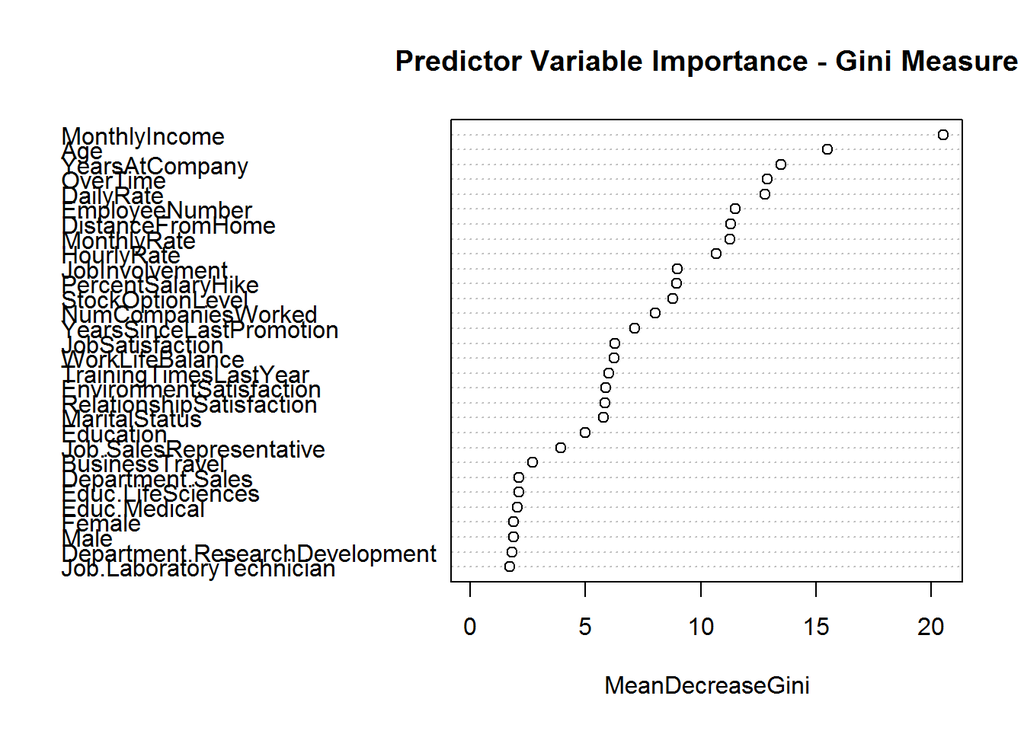

```r
# Random Forest to show variables in order of importance for determining Attrtion (all variable transformations and eliminations have already taken place at this point)
Important_Variables.varFiltered <- randomForest(Attrition ~., data = data.Employee.varFiltered, importance = T)

#build the Variable Importance Plot
varImpPlot(Important_Variables.varFiltered, main = "Predictor Variable Importance - Gini Measure", type=2)
```

# Addressing the Top Three Variables: Boxplots for Gini

### Based on the Gini analysis, here are the top three variables that have the highest influence on `attrition`. Boxplots do a great job of displaying the distribution of data, along with variation and quartiles, including the interquartile range.

#### b) With respect to the `Attrition` vs. `Monthly Income` plot, employees who earn less, are much more likely to leave their jobs. Once an employee begins having a monthly income of a little more than roughly $5,000, the employee is much less likely to leave their job. For perspective, the employee who leaves is at a median of roughly $3,000 per month with the 50th percentile spanning from roughly $2,500 to $5,500 per month. The employee who stays is at a median of roughly $5,200 to $9,000 per month.

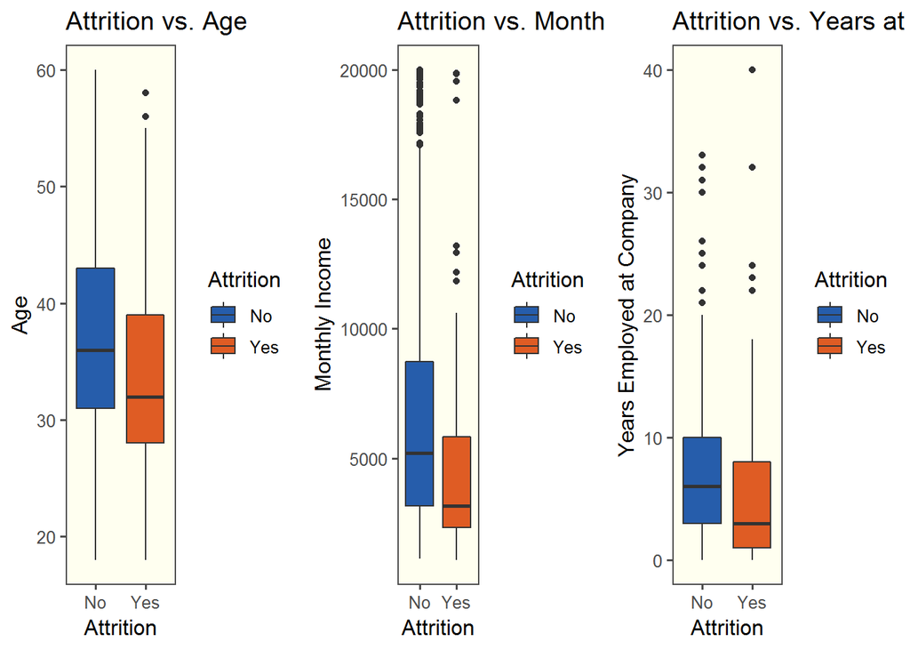

```r
data.Employee %>% keep(is.factor) %>% names -> label

bw1 <- ggplot(data = data.nonTransformed, aes(x = Attrition, y = Age, fill = Attrition)) + geom_boxplot() + scale_fill_few(palette = "Dark") + theme_few() + ggtitle("Attrition vs. Age") + theme(panel.background = element_rect(fill = 'ivory1'))

bw2 <- ggplot(data = data.nonTransformed, aes(x = Attrition, y = MonthlyIncome, fill = Attrition)) + geom_boxplot() + scale_fill_few(palette = "Dark") + theme_few() + ggtitle("Attrition vs. Monthly Income") + theme(panel.background = element_rect(fill = 'ivory1')) + ylab("Monthly Income")

bw3 <- ggplot(data = data.nonTransformed, aes(x = Attrition, y = YearsAtCompany, fill = Attrition)) + geom_boxplot() + scale_fill_few(palette = "Dark") + theme_few() + ggtitle("Attrition vs. Years at Company") + theme(panel.background = element_rect(fill = 'ivory1')) + ylab("Years Employed at Company")

par(oma=c(0.1,0.1,2.1,0))
plot_grid(bw1,bw2,bw3, ncol = 3, rel_widths = c(1,1,1))
```

# k-Nearest Neighbors, Naive Bayes, & Multiple Linear Regression Model Development

### Here, I test a `k-NN` model using cross-validation from the `data.Employee.varFiltered` dataset. The data is partitioned into 70% training data and 30% testing data.

#### Create Test and Train data - Attrition

```r
data.Employee.varFiltered <- data.Employee.varFiltered %>% subset(select=c(-BusinessTravel,-Department.HumanResources,-Department.ResearchDevelopment,-Department.Sales))

# Set seed while tuning
#set.seed(123)

#partitioning out the test/train data set
dataPartition.varFiltered.Attrition <- createDataPartition(y=data.Employee.varFiltered$Attrition, p=0.7, list = F)

# 70% Training
dfTrain.filtered.Attrition <- data.Employee.varFiltered[dataPartition.varFiltered.Attrition,]

# 30% Testing
dfTest.filtered.Attrition <- data.Employee.varFiltered[-dataPartition.varFiltered.Attrition,]
```

```r
# For optional parallel processing:
# parallel::detectCores() # detected 8 cores available
# workers <- makeCluster(6L) # distribute across 6 of 8 cores in parallel
# registerDoParallel(workers) # invoke
```

# Set the training control parameters

### For both the `k-NN` and `Naive Bayes` models, cross-validation was performed 125 times, using 5 repetitions of 25 folds. The `twoClassSummary` function was used for training toward specificity (which could be modified to tune toward sensitivity), meaning the data used was partitioned into 25 units of test data, repeated 5 times with a repartitioning of the folds for each repeat. After thorough testing, these parameters were determined ideal for both. Since the same data only has rows in the hundreds, this is not alarming; if the data were millions of rows, this may require varying levels of folds and repetitions.

```r
# repeated cross validation 125 times
train.Control <- trainControl(method = "repeatedcv",
                              number = 25,
                              repeats = 5,
                              summaryFunction = twoClassSummary,
                              classProbs = T)
```

# Perform k-Nearest Neighbors, Build Confusion Matrix

```r
# Setting up the knn model tune parameters, tuned to specificity with pre-processing.
knn_fit.filtered.Attrition <- train(Attrition ~ .
                , data = dfTrain.filtered.Attrition
                , method = "knn"
                , trControl=train.Control
                , preProcess = c("center", "scale", "spatialSign")
                , metric = "Spec"
                 )

knn_fit.filtered.Attrition
```

```
## k-Nearest Neighbors
##
## 609 samples
##  38 predictor
##   2 classes: 'No', 'Yes'
##
## Pre-processing: centered (38), scaled (38), spatial sign
##  transformation (38)
## Resampling: Cross-Validated (25 fold, repeated 5 times)
## Summary of sample sizes: 584, 584, 584, 585, 585, 584, ...
## Resampling results across tuning parameters:
##
##   k  ROC        Sens       Spec
##   5  0.7192103  0.9623238  0.2900000
##   7  0.7272627  0.9732952  0.2280000
##   9  0.7318817  0.9827238  0.1733333
##
## Spec was used to select the optimal model using the largest value.
## The final value used for the model was k = 5.
```

```r
test_pred.knn.filtered.Attrition <- predict(knn_fit.filtered.Attrition, newdata = dfTest.filtered.Attrition)

confusionMatrix(table(test_pred.knn.filtered.Attrition, dfTest.filtered.Attrition$Attrition))
```

```
## Confusion Matrix and Statistics
##
##
## test_pred.knn.filtered.Attrition  No Yes
##                              No  215  36
##                              Yes   4   6
##
##                Accuracy : 0.8467
##                  95% CI : (0.7972, 0.8882)
##     No Information Rate : 0.8391
##     P-Value [Acc > NIR] : 0.4072
##
##                   Kappa : 0.18
##
##  Mcnemar's Test P-Value : 9.509e-07
##
##             Sensitivity : 0.9817
##             Specificity : 0.1429
##          Pos Pred Value : 0.8566
##          Neg Pred Value : 0.6000
##              Prevalence : 0.8391
##          Detection Rate : 0.8238
##    Detection Prevalence : 0.9617
##       Balanced Accuracy : 0.5623
##
##        'Positive' Class : No
##
```

# Perform Naive Bayes (Attrition), confusion matrix for analysis

### The second model employed the `Naive Bayes` algorithm. `Naive Bayes` is a probabilistic classifier that has strong assumptions requiring independence. For this reason, it was especially important to remove correlated predictors. Overall, this model produced a sensitivity and specificity each above 60%. Consequently, `Naive Bayes` was selected over `k-NN` for predicting Attrition.

```r
nb_fit.filtered <- suppressWarnings(train(Attrition ~ .
                          , data = dfTrain.filtered.Attrition
                          , method = "nb"
                          , trControl=train.Control
                          , preProcess = c("center", "scale", "spatialSign")
                          , metric = "Spec"))

nb_fit.filtered
```

```
## Naive Bayes
##
## 609 samples
##  38 predictor
##   2 classes: 'No', 'Yes'
##
## Pre-processing: centered (38), scaled (38), spatial sign
##  transformation (38)
## Resampling: Cross-Validated (25 fold, repeated 5 times)
## Summary of sample sizes: 585, 585, 585, 585, 584, 584, ...
## Resampling results across tuning parameters:
##
##   usekernel  ROC        Sens       Spec
##   FALSE      0.7496810  0.6152190  0.7526667
##    TRUE      0.7081357  0.9388762  0.2006667
##
## Tuning parameter 'fL' was held constant at a value of 0
## Tuning
##  parameter 'adjust' was held constant at a value of 1
## Spec was used to select the optimal model using the largest value.
## The final values used for the model were fL = 0, usekernel = FALSE
##  and adjust = 1.
```

```r
test_pred.nb.filtered <- suppressWarnings(predict(nb_fit.filtered, newdata = dfTrain.filtered.Attrition))

confusionMatrix(table(test_pred.nb.filtered, dfTrain.filtered.Attrition$Attrition))
```

```
## Confusion Matrix and Statistics
##
##
## test_pred.nb.filtered  No Yes
##                   No  330  16
##                   Yes 181  82
##
##                Accuracy : 0.6765
##                  95% CI : (0.6378, 0.7136)
##     No Information Rate : 0.8391
##     P-Value [Acc > NIR] : 1
##
##                   Kappa : 0.2872
##
##  Mcnemar's Test P-Value : <2e-16
##
##             Sensitivity : 0.6458
##             Specificity : 0.8367
##          Pos Pred Value : 0.9538
##          Neg Pred Value : 0.3118
##              Prevalence : 0.8391
##          Detection Rate : 0.5419
##    Detection Prevalence : 0.5681
##       Balanced Accuracy : 0.7413
##
##        'Positive' Class : No
##
```

# Set-Up for Attrition Test Data (Includes Transformations and Variable Updates)

### All data being tested against must undergo the same variable transformations performed during training. As a result, the same procedures were copied and renamed to ingest a dataframe called data.Test.

```r
# Converting all char classes to factor and all int classes to numeric for uniformity in processing and predicting
data.Test.Attrition <- data.Test.Attrition %>% mutate_if(is.integer, as.numeric) %>% mutate_if(is.character, as.factor) %>% data.frame()

# Remove all factors with only one level and ID
data.EmployeeN <- data.Test.Attrition %>% subset(select=c(-Over18, -StandardHours, -EmployeeCount))

#convert ranges
data.EmployeeN$MonthlyIncome <- log(data.EmployeeN$MonthlyIncome)
data.EmployeeN$YearsAtCompany <- log(data.EmployeeN$YearsAtCompany+1)
data.EmployeeN$Age <- log(data.EmployeeN$Age)
data.EmployeeN$DistanceFromHome <- log(data.EmployeeN$DistanceFromHome)
data.EmployeeN$PercentSalaryHike <- log(data.EmployeeN$PercentSalaryHike)
data.EmployeeN$YearsSinceLastPromotion <- log(data.EmployeeN$YearsSinceLastPromotion+1)

data.Employee3 <- data.EmployeeN

############################################################################
########################## Department dummy variable creation###############
############################################################################
DepartmentN <- data.frame(data.Employee3$Department)
DepartmentN <- suppressWarnings(dummy.data.frame(DepartmentN))
#levels(data.Employee3$Department)
colnames(DepartmentN) <- c("Department.HumanResources","Department.ResearchDevelopment","Department.Sales")

data.Employee3 <- cbind(data.Employee3,DepartmentN)
data.Employee3 <- data.Employee3 %>% subset(select=-Department)
#colnames(data.Employee3)
############################################################################
############################################################################
############################################################################

############################################################################
########################## Education Field dummy variable creation##########
############################################################################
EducationField <- data.frame(data.Employee3$EducationField)
EducationField <- suppressWarnings(dummy.data.frame(EducationField))
#levels(data.Employee3$EducationField)
colnames(EducationField) <- c("Educ.HumanResources","Educ.LifeSciences","Educ.Marketing","Educ.Medical","Educ.Other","Educ.TechnicalDegree")

data.Employee3 <- cbind(data.Employee3,EducationField)
data.Employee3 <- data.Employee3 %>% subset(select=-EducationField)
#colnames(data.Employee3)
############################################################################
############################################################################
############################################################################

############################################################################
########################## Job Role dummy variable creation#################
############################################################################
JobRole <- data.frame(data.Employee3$JobRole)
JobRole <- suppressWarnings(dummy.data.frame(JobRole))
#levels(data.Employee3$JobRole)
colnames(JobRole) <- c("Job.HealthcareRepresentative","Job.HumanResources","Job.LaboratoryTechnician","Job.Manager","Job.ManufacturingDirector","Job.ResearchDirector","Job.ResearchScientist","Job.SalesExecutive","Job.SalesRepresentative")

data.Employee3 <- cbind(data.Employee3,JobRole)
data.Employee3 <- data.Employee3 %>% subset(select=-JobRole)
#colnames(data.Employee3)
############################################################################
############################################################################
############################################################################

############################################################################
########################## Gender dummy variable creation###################
############################################################################
Gender <- data.frame(data.Employee3$Gender)
Gender <- suppressWarnings(dummy.data.frame(Gender))
#levels(data.Employee3$JobRole)
colnames(Gender) <- c("Male","Female")

data.Employee3 <- cbind(data.Employee3,Gender)
data.Employee3 <- data.Employee3 %>% subset(select=-Gender)
#colnames(data.Employee3)
############################################################################
############################################################################
############################################################################

# Recode BusinessTravel with numerical representation of ordinal factor levels
data.Employee3$BusinessTravel <- dplyr::recode(data.Employee3$BusinessTravel, `Non-Travel`="0", `Travel_Rarely`="1", `Travel_Frequently`="2")

# Recode MaritalStatus with numerical representation of ordinal factor levels
data.Employee3$MaritalStatus <- dplyr::recode(data.Employee3$MaritalStatus, `Single`="1", `Married`="2", `Divorced`="3")

# Recode OverTime with numerical representation of ordinal factor levels
data.Employee3$OverTime <- dplyr::recode(data.Employee3$OverTime, `Yes`="1", `No`="0")

# Recode Attrition with numerical representation of ordinal factor levels
#data.Employee3$Attrition <- dplyr::recode(data.Employee3$Attrition, `Yes`="1", `No`="0")

data.Employee3$BusinessTravel <- as.integer(data.Employee3$BusinessTravel)
data.Employee3$MaritalStatus <- as.integer(data.Employee3$MaritalStatus)
data.Employee3$OverTime <- as.integer(data.Employee3$OverTime)

data.Employee3 <- data.Employee3 %>% subset(select=c(-BusinessTravel,-Department.HumanResources,-Department.ResearchDevelopment,-Department.Sales))
```

# Predicting Attrition with the Model

```r
#############################################################################################
################################## Testing Zone #############################################
#############################################################################################

# apply the Naive Bayes model to predict future attrition
data.Employee3$Attrition <- suppressWarnings(predict(nb_fit.filtered, newdata = data.Employee3))

# frame the predictions with corresponding IDs from the data.Employee3 dataset, rename
submit_Preds <- data.frame(data.Employee3$ID,data.Employee3$Attrition)
submit_Preds <- data.Employee3 %>% subset(select=c(ID, Attrition))

# write out the results to csv saved in wd
write.csv(submit_Preds, "Case2PredictionsAdams Attrition.csv", row.names=F)
#############################################################################################
#############################################################################################
#############################################################################################
```

# Variable Selection for Linear Regression

### This is necessary for predicting MonthlyIncome since this is not binary classification; it is relatively continuous.

```r
#############################################################################
####################### Linear Model Creation ###############################
#############################################################################
model2.forward.Start <- lm(MonthlyIncome~1, data = data.Employee.Regression)

model2.Allvar <- lm(MonthlyIncome ~ Age + Attrition + BusinessTravel + DailyRate + Department + DistanceFromHome + Education + EducationField + EmployeeNumber + EnvironmentSatisfaction + Gender + HourlyRate + JobInvolvement + JobLevel + JobRole + JobSatisfaction + MaritalStatus + MonthlyRate + NumCompaniesWorked + OverTime + PercentSalaryHike + PerformanceRating + RelationshipSatisfaction + StockOptionLevel + TotalWorkingYears + TrainingTimesLastYear + WorkLifeBalance + YearsAtCompany + YearsInCurrentRole + YearsSinceLastPromotion + YearsWithCurrManager, data=data.Employee.Regression)
#############################################################################
#############################################################################
#############################################################################

#############################################################################
######## Akaike Information Criterion for Variable Selection Process#########
#############################################################################

#### Forward Selection
model2.Forward <- stepAIC(model2.forward.Start, direction = "forward", trace = F, scope = formula(model2.Allvar))

summary(model2.Forward)
```

```
##
## Call:
## lm(formula = MonthlyIncome ~ JobLevel + JobRole + TotalWorkingYears +
##     BusinessTravel + Gender + DailyRate + MonthlyRate + YearsWithCurrManager +
##     YearsSinceLastPromotion + DistanceFromHome + EmployeeNumber,
##     data = data.Employee.Regression)
##
## Residuals:
##     Min      1Q  Median      3Q     Max
## -3805.3  -654.3   -21.2   618.1  3997.2
##
## Coefficients:
##                                   Estimate Std. Error t value Pr(>|t|)
## (Intercept)                     -4.625e+02  2.618e+02  -1.766 0.077721 .
## JobLevel                         2.794e+03  8.096e+01  34.512  < 2e-16 ***
## JobRoleHuman Resources          -3.867e+02  2.492e+02  -1.552 0.121119
## JobRoleLaboratory Technician    -5.911e+02  1.673e+02  -3.533 0.000433 ***
## JobRoleManager                   4.002e+03  2.282e+02  17.534  < 2e-16 ***
## JobRoleManufacturing Director    1.718e+02  1.658e+02   1.036 0.300557
## JobRoleResearch Director         4.050e+03  2.144e+02  18.891  < 2e-16 ***
## JobRoleResearch Scientist       -3.312e+02  1.674e+02  -1.979 0.048189 *
## JobRoleSales Executive          -4.462e+01  1.426e+02  -0.313 0.754460
## JobRoleSales Representative     -4.304e+02  2.101e+02  -2.048 0.040823 *
## TotalWorkingYears                4.832e+01  8.458e+00   5.713 1.54e-08 ***
## BusinessTravelTravel_Frequently  2.094e+02  1.382e+02   1.515 0.130169
## BusinessTravelTravel_Rarely      3.840e+02  1.170e+02   3.282 0.001072 **
## GenderMale                       1.176e+02  7.314e+01   1.608 0.108220
## DailyRate                        1.651e-01  8.937e-02   1.847 0.065110 .
## MonthlyRate                     -9.419e-03  5.045e-03  -1.867 0.062240 .
## YearsWithCurrManager            -2.876e+01  1.236e+01  -2.327 0.020210 *
## YearsSinceLastPromotion          2.950e+01  1.369e+01   2.154 0.031485 *
## DistanceFromHome                -6.541e+00  4.399e+00  -1.487 0.137395
## EmployeeNumber                   8.393e-02  5.939e-02   1.413 0.157928
## ---
## Signif. codes:  0 '***' 0.001 '**' 0.01 '*' 0.05 '.' 0.1 ' ' 1
##
## Residual standard error: 1048 on 850 degrees of freedom
## Multiple R-squared:  0.9492, Adjusted R-squared:  0.9481
## F-statistic:   836 on 19 and 850 DF,  p-value: < 2.2e-16
```

```r
model2.Forward$anova
```

```
## Stepwise Model Path
## Analysis of Deviance Table
##
## Initial Model:
## MonthlyIncome ~ 1
##
## Final Model:
## MonthlyIncome ~ JobLevel + JobRole + TotalWorkingYears + BusinessTravel +
##     Gender + DailyRate + MonthlyRate + YearsWithCurrManager +
##     YearsSinceLastPromotion + DistanceFromHome + EmployeeNumber
##
##
##                         Step Df    Deviance Resid. Df  Resid. Dev      AIC
## 1                                                 869 18369624387 14674.96
## 2                 + JobLevel  1 16635876873       868  1733747514 12623.40
## 3                  + JobRole  8   722387200       860  1011360314 12170.48
## 4        + TotalWorkingYears  1    41160686       859   970199629 12136.33
## 5           + BusinessTravel  2    14325268       857   955874361 12127.39
## 6                   + Gender  1     3626204       856   952248157 12126.08
## 7                + DailyRate  1     3469185       855   948778972 12124.91
## 8              + MonthlyRate  1     3151924       854   945627047 12124.01
## 9     + YearsWithCurrManager  1     2669941       853   942957107 12123.55
## 10 + YearsSinceLastPromotion  1     5268371       852   937688736 12120.68
## 11        + DistanceFromHome  1     2446145       851   935242592 12120.41
## 12          + EmployeeNumber  1     2192636       850   933049956 12120.36
```

```r
#### suggested Forward Selection Model
forward.lm <- lm(MonthlyIncome ~ JobLevel + JobRole + TotalWorkingYears + BusinessTravel + Gender + DailyRate + MonthlyRate + YearsWithCurrManager + YearsSinceLastPromotion + DistanceFromHome + EmployeeNumber, data=data.Employee.Regression)
########################################################################

#### Backward Elimination
model2.Backward <- stepAIC(model2.Allvar, direction = "backward", trace = F, scope = formula(model2.forward.Start))
summary(model2.Backward)
```

```
##
## Call:
## lm(formula = MonthlyIncome ~ BusinessTravel + DailyRate + DistanceFromHome +
##     EmployeeNumber + Gender + JobLevel + JobRole + MonthlyRate +
##     PercentSalaryHike + PerformanceRating + TotalWorkingYears +
##     YearsSinceLastPromotion + YearsWithCurrManager, data = data.Employee.Regression)
##
## Residuals:
##     Min      1Q  Median      3Q     Max
## -3862.6  -660.0     0.8   632.5  4053.6
##
## Coefficients:
##                                   Estimate Std. Error t value Pr(>|t|)
## (Intercept)                      1.508e+02  4.470e+02   0.337 0.735933
## BusinessTravelTravel_Frequently  2.247e+02  1.383e+02   1.624 0.104692
## BusinessTravelTravel_Rarely      3.892e+02  1.169e+02   3.329 0.000909 ***
## DailyRate                        1.536e-01  8.950e-02   1.716 0.086457 .
## DistanceFromHome                -6.671e+00  4.402e+00  -1.516 0.129994
## EmployeeNumber                   8.423e-02  5.935e-02   1.419 0.156229
## GenderMale                       1.138e+02  7.310e+01   1.557 0.119771
## JobLevel                         2.789e+03  8.103e+01  34.414  < 2e-16 ***
## JobRoleHuman Resources          -3.870e+02  2.491e+02  -1.553 0.120691
## JobRoleLaboratory Technician    -5.852e+02  1.674e+02  -3.496 0.000497 ***
## JobRoleManager                   4.034e+03  2.287e+02  17.635  < 2e-16 ***
## JobRoleManufacturing Director    1.800e+02  1.658e+02   1.086 0.277978
## JobRoleResearch Director         4.047e+03  2.142e+02  18.895  < 2e-16 ***
## JobRoleResearch Scientist       -3.426e+02  1.674e+02  -2.047 0.041002 *
## JobRoleSales Executive          -3.591e+01  1.426e+02  -0.252 0.801263
## JobRoleSales Representative     -4.492e+02  2.103e+02  -2.136 0.032985 *
## MonthlyRate                     -9.481e-03  5.040e-03  -1.881 0.060288 .
## PercentSalaryHike                2.419e+01  1.553e+01   1.557 0.119793
## PerformanceRating               -3.069e+02  1.589e+02  -1.931 0.053794 .
## TotalWorkingYears                4.818e+01  8.450e+00   5.702 1.64e-08 ***
## YearsSinceLastPromotion          2.978e+01  1.369e+01   2.175 0.029877 *
## YearsWithCurrManager            -2.809e+01  1.236e+01  -2.273 0.023260 *
## ---
## Signif. codes:  0 '***' 0.001 '**' 0.01 '*' 0.05 '.' 0.1 ' ' 1
##
## Residual standard error: 1047 on 848 degrees of freedom
## Multiple R-squared:  0.9494, Adjusted R-squared:  0.9482
## F-statistic: 758.1 on 21 and 848 DF,  p-value: < 2.2e-16
```

```r
model2.Backward$anova
```

```
## Stepwise Model Path
## Analysis of Deviance Table
##
## Initial Model:
## MonthlyIncome ~ Age + Attrition + BusinessTravel + DailyRate +
##     Department + DistanceFromHome + Education + EducationField +
##     EmployeeNumber + EnvironmentSatisfaction + Gender + HourlyRate +
##     JobInvolvement + JobLevel + JobRole + JobSatisfaction + MaritalStatus +
##     MonthlyRate + NumCompaniesWorked + OverTime + PercentSalaryHike +
##     PerformanceRating + RelationshipSatisfaction + StockOptionLevel +
##     TotalWorkingYears + TrainingTimesLastYear + WorkLifeBalance +
##     YearsAtCompany + YearsInCurrentRole + YearsSinceLastPromotion +
##     YearsWithCurrManager
##
## Final Model:
## MonthlyIncome ~ BusinessTravel + DailyRate + DistanceFromHome +
##     EmployeeNumber + Gender + JobLevel + JobRole + MonthlyRate +
##     PercentSalaryHike + PerformanceRating + TotalWorkingYears +
##     YearsSinceLastPromotion + YearsWithCurrManager
##
##
##                          Step Df     Deviance Resid. Df Resid. Dev
## 1                                                   824  919434052
## 2            - EducationField  5 1.988941e+06       829  921422993
## 3             - MaritalStatus  2 6.743471e+05       831  922097340
## 4          - StockOptionLevel  1 4.472277e+01       832  922097385
## 5                       - Age  1 1.438683e+04       833  922111772
## 6                - HourlyRate  1 1.996957e+04       834  922131741
## 7   - EnvironmentSatisfaction  1 3.281011e+04       835  922164552
## 8        - NumCompaniesWorked  1 7.012996e+04       836  922234682
## 9                  - OverTime  1 8.564508e+04       837  922320327
## 10           - JobInvolvement  1 1.382286e+05       838  922458555
## 11 - RelationshipSatisfaction  1 2.293225e+05       839  922687878
## 12       - YearsInCurrentRole  1 2.311677e+05       840  922919045
## 13           - YearsAtCompany  1 1.344462e+05       841  923053492
## 14    - TrainingTimesLastYear  1 3.946668e+05       842  923448158
## 15                - Attrition  1 4.391914e+05       843  923887350
## 16          - WorkLifeBalance  1 6.108920e+05       844  924498242
## 17          - JobSatisfaction  1 6.418043e+05       845  925140046
## 18               - Department  2 2.882134e+06       847  928022180
## 19                - Education  1 9.338310e+05       848  928956011
##         AIC
## 1  12159.57
## 2  12151.45
## 3  12148.09
## 4  12146.09
## 5  12144.10
## 6  12142.12
## 7  12140.15
## 8  12138.22
## 9  12136.30
## 10 12134.43
## 11 12132.65
## 12 12130.87
## 13 12128.99
## 14 12127.36
## 15 12125.78
## 16 12124.35
## 17 12122.96
## 18 12121.66
## 19 12120.54
```

```r
#### Backward Elimination Model Suggestion
back.lm <- lm(MonthlyIncome ~ BusinessTravel + DailyRate + DistanceFromHome +
    EmployeeNumber + Gender + JobLevel + JobRole + MonthlyRate +
    PercentSalaryHike + PerformanceRating + TotalWorkingYears +
    YearsSinceLastPromotion + YearsWithCurrManager, data=data.Employee.Regression)
########################################################################

#### Stepwise Regression
model2.Stepwise <- stepAIC(model2.Allvar, direction = "both", trace = F)
summary(model2.Stepwise)
```

```
##
## Call:
## lm(formula = MonthlyIncome ~ BusinessTravel + DailyRate + DistanceFromHome +
##     EmployeeNumber + Gender + JobLevel + JobRole + MonthlyRate +
##     PercentSalaryHike + PerformanceRating + TotalWorkingYears +
##     YearsSinceLastPromotion + YearsWithCurrManager, data = data.Employee.Regression)
##
## Residuals:
##     Min      1Q  Median      3Q     Max
## -3862.6  -660.0     0.8   632.5  4053.6
##
## Coefficients:
##                                   Estimate Std. Error t value Pr(>|t|)
## (Intercept)                      1.508e+02  4.470e+02   0.337 0.735933
## BusinessTravelTravel_Frequently  2.247e+02  1.383e+02   1.624 0.104692
## BusinessTravelTravel_Rarely      3.892e+02  1.169e+02   3.329 0.000909 ***
## DailyRate                        1.536e-01  8.950e-02   1.716 0.086457 .
## DistanceFromHome                -6.671e+00  4.402e+00  -1.516 0.129994
## EmployeeNumber                   8.423e-02  5.935e-02   1.419 0.156229
## GenderMale                       1.138e+02  7.310e+01   1.557 0.119771
## JobLevel                         2.789e+03  8.103e+01  34.414  < 2e-16 ***
## JobRoleHuman Resources          -3.870e+02  2.491e+02  -1.553 0.120691
## JobRoleLaboratory Technician    -5.852e+02  1.674e+02  -3.496 0.000497 ***
## JobRoleManager                   4.034e+03  2.287e+02  17.635  < 2e-16 ***
## JobRoleManufacturing Director    1.800e+02  1.658e+02   1.086 0.277978
## JobRoleResearch Director         4.047e+03  2.142e+02  18.895  < 2e-16 ***
## JobRoleResearch Scientist       -3.426e+02  1.674e+02  -2.047 0.041002 *
## JobRoleSales Executive          -3.591e+01  1.426e+02  -0.252 0.801263
## JobRoleSales Representative     -4.492e+02  2.103e+02  -2.136 0.032985 *
## MonthlyRate                     -9.481e-03  5.040e-03  -1.881 0.060288 .
## PercentSalaryHike                2.419e+01  1.553e+01   1.557 0.119793
## PerformanceRating               -3.069e+02  1.589e+02  -1.931 0.053794 .
## TotalWorkingYears                4.818e+01  8.450e+00   5.702 1.64e-08 ***
## YearsSinceLastPromotion          2.978e+01  1.369e+01   2.175 0.029877 *
## YearsWithCurrManager            -2.809e+01  1.236e+01  -2.273 0.023260 *
## ---
## Signif. codes:  0 '***' 0.001 '**' 0.01 '*' 0.05 '.' 0.1 ' ' 1
##
## Residual standard error: 1047 on 848 degrees of freedom
## Multiple R-squared:  0.9494, Adjusted R-squared:  0.9482
## F-statistic: 758.1 on 21 and 848 DF,  p-value: < 2.2e-16
```

```r
model2.Stepwise$anova
```

```
## Stepwise Model Path
## Analysis of Deviance Table
##
## Initial Model:
## MonthlyIncome ~ Age + Attrition + BusinessTravel + DailyRate +
##     Department + DistanceFromHome + Education + EducationField +
##     EmployeeNumber + EnvironmentSatisfaction + Gender + HourlyRate +
##     JobInvolvement + JobLevel + JobRole + JobSatisfaction + MaritalStatus +
##     MonthlyRate + NumCompaniesWorked + OverTime + PercentSalaryHike +
##     PerformanceRating + RelationshipSatisfaction + StockOptionLevel +
##     TotalWorkingYears + TrainingTimesLastYear + WorkLifeBalance +
##     YearsAtCompany + YearsInCurrentRole + YearsSinceLastPromotion +
##     YearsWithCurrManager
##
## Final Model:
## MonthlyIncome ~ BusinessTravel + DailyRate + DistanceFromHome +
##     EmployeeNumber + Gender + JobLevel + JobRole + MonthlyRate +
##     PercentSalaryHike + PerformanceRating + TotalWorkingYears +
##     YearsSinceLastPromotion + YearsWithCurrManager
##
##
##                          Step Df     Deviance Resid. Df Resid. Dev
## 1                                                   824  919434052
## 2            - EducationField  5 1.988941e+06       829  921422993
## 3             - MaritalStatus  2 6.743471e+05       831  922097340
## 4          - StockOptionLevel  1 4.472277e+01       832  922097385
## 5                       - Age  1 1.438683e+04       833  922111772
## 6                - HourlyRate  1 1.996957e+04       834  922131741
## 7   - EnvironmentSatisfaction  1 3.281011e+04       835  922164552
## 8        - NumCompaniesWorked  1 7.012996e+04       836  922234682
## 9                  - OverTime  1 8.564508e+04       837  922320327
## 10           - JobInvolvement  1 1.382286e+05       838  922458555
## 11 - RelationshipSatisfaction  1 2.293225e+05       839  922687878
## 12       - YearsInCurrentRole  1 2.311677e+05       840  922919045
## 13           - YearsAtCompany  1 1.344462e+05       841  923053492
## 14    - TrainingTimesLastYear  1 3.946668e+05       842  923448158
## 15                - Attrition  1 4.391914e+05       843  923887350
## 16          - WorkLifeBalance  1 6.108920e+05       844  924498242
## 17          - JobSatisfaction  1 6.418043e+05       845  925140046
## 18               - Department  2 2.882134e+06       847  928022180
## 19                - Education  1 9.338310e+05       848  928956011
##         AIC
## 1  12159.57
## 2  12151.45
## 3  12148.09
## 4  12146.09
## 5  12144.10
## 6  12142.12
## 7  12140.15
## 8  12138.22
## 9  12136.30
## 10 12134.43
## 11 12132.65
## 12 12130.87
## 13 12128.99
## 14 12127.36
## 15 12125.78
## 16 12124.35
## 17 12122.96
## 18 12121.66
## 19 12120.54
```

```r
#### Stepwise Regression Model Suggestion
step.lm <- lm(MonthlyIncome ~ BusinessTravel + DailyRate + DistanceFromHome +
    EmployeeNumber + Gender + JobLevel + JobRole + MonthlyRate +
    PercentSalaryHike + PerformanceRating + TotalWorkingYears +
    YearsSinceLastPromotion + YearsWithCurrManager, data=data.Employee.Regression)
########################################################################
```

# Calculated Root Mean Square Error (RMSE) for Forward Selection Model:

### Based on the `Residuals` and `QQ plots`, variance from the `Forward Selection` model seems mostly constant with a normal distrubtion of fitted residuals. There are two outliers with leverage, but without further analysis, it would be difficult to determine if these plots are due to accident (such as a typo or data conversion issue, for example) or if they’re truly outliers.

```r
Forward.RMSE <- sqrt(mean(forward.lm$residuals^2))
Forward.RMSE
```

```
## [1] 1035.602
```

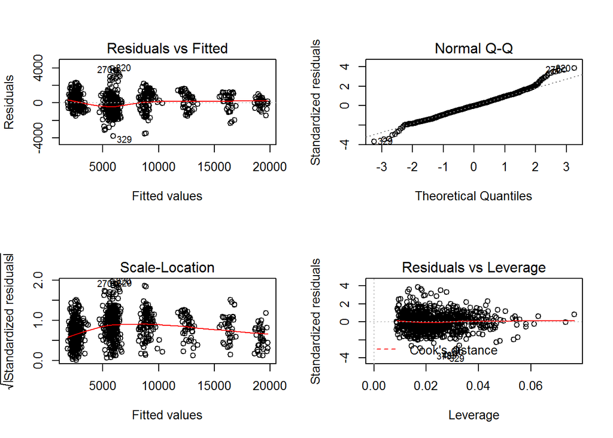

```r
par(mfrow=c(2,2))
plot(forward.lm)
```

# Calculated Root Mean Square Error (RMSE) for Backward Elimination Model

### As with the forward selection model - which produces a slightly higher `Root Mean Square Error` - variance seems mostly constant with a normal distrubtion of fitted residuals. There are two outliers with leverage, but without further analysis, it would be difficult to determine if these plots are due to accident (such as a typo or data conversion issue, for example) or if they’re truly outliers. Coupled with the outlier’s leverage compared to the `Cook's Distance`, the slightly non-constant variance and tails in the distribution of residuals could be worth tuning for future updates.

```r
Backward.RMSE <- sqrt(mean(back.lm$residuals^2))
Backward.RMSE
```

```
## [1] 1033.327
```

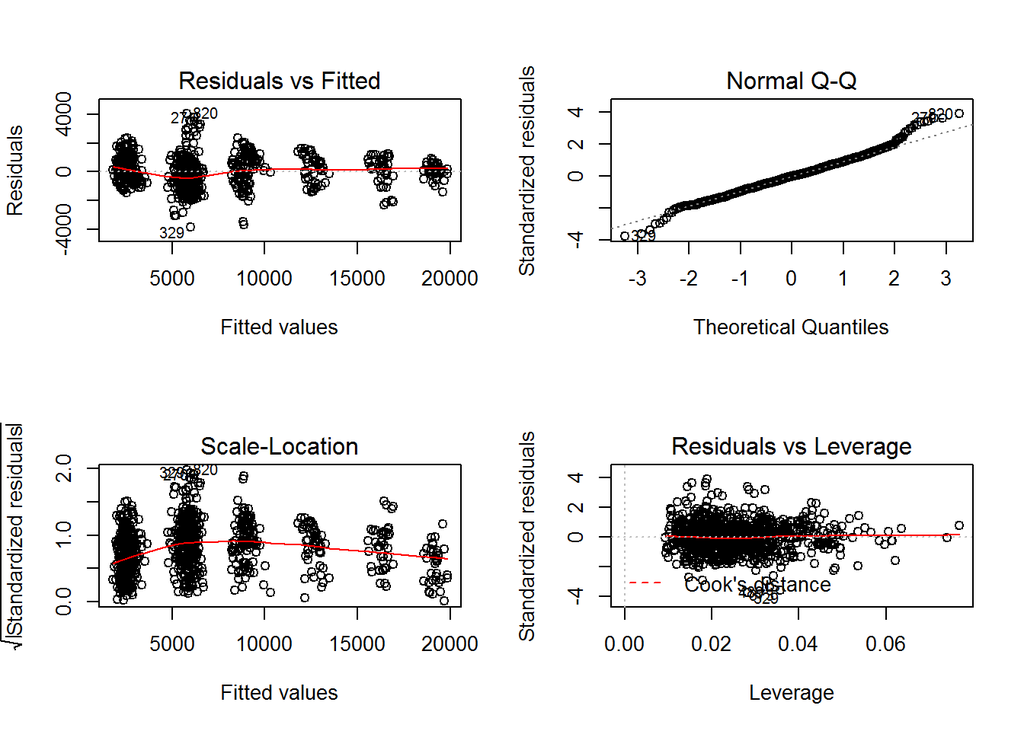

```r
par(mfrow=c(2,2))
plot(back.lm)
```

# Calculated RMSE for `Stepwise Regression` Model

### Ultimately, because the `Root Mean Square Error` was smaller with the `Backward Elimination` and `Stepwise Regression` models, we selected to move forward with predcition using the model selected by `Stepwise Regression`. Should model refinement be needed, investigating the outliers and considering further transformations could prove profitable.

```r
Stepwise.RMSE <- sqrt(mean(step.lm$residuals^2))
Stepwise.RMSE
```

```
## [1] 1033.327
```

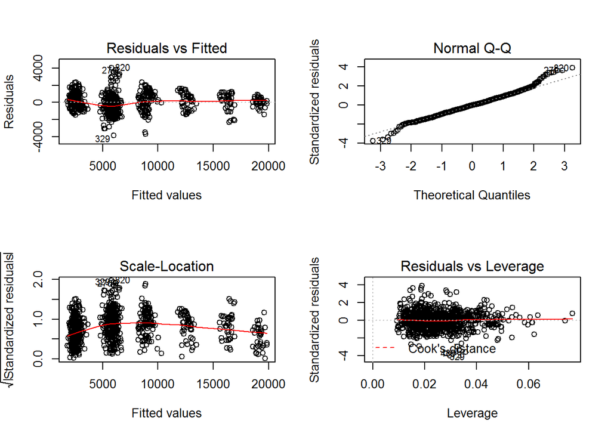

```r
par(mfrow=c(2,2))
plot(step.lm)
```

# Multiple Linear Regression Predictions

### Here, the multiple linear regression model is employing the model chosen by `Stepwise Regression` top make predictions on the salary information provided in the competition set.

```r
# Apply the model to the test set to provide predicted salary values
data.Test.Income$Salary <- predict.lm(step.lm, data.Test.Income)
Case2Predictions <- data.frame(data.Test.Income$ID,data.Test.Income$Salary)

Case2Predictions <- data.Test.Income %>% subset(select=c(ID, Salary))

write.csv(Case2Predictions, "Case2PredictionsAdams Salary.csv", row.names=F)
```